# Practical Machine Learning - Course Project

Vladimir Sazontov

Monday, June 15, 2015

### Executive summary

This report is a compiled (using knitr) R markdown document issued within the framework of the project for the course “Practical Machine Learning” introduced by Johns Hopkins University through Coursera.

The context of the project is as follows. The initital data for analysis represents measurements of accelerometers on the belt, forearm, arm, and dumbell of 6 participants who were asked to perform barbell lifts correctly and incorrectly in 5 different ways. The source of original data: http://groupware.les.inf.puc-rio.br/har.

The goal of the current project is to predict the manner in which participants did the exercise (the “classe” variable in the corresponding training set).

The task is performed in R using **rpart** and **randomForest** libraries. The report describes the applied models, their cross validation and prediction of 20 different cases. The best model appeared to be Random Forest with the out of sample error less than 1%.

### Initial Data Processing

First, let’s initialize necessary packages:

```r
library(knitr)
library(rpart)
library(rpart.plot)
library(rattle)
library(caret)
library(corrplot)
library(kernlab)
library(randomForest)
```

Download and clean the data:

```r
# URL and destination files
fileUrlTrain <- "http://d396qusza40orc.cloudfront.net/predmachlearn/pml-training.csv"
destfileTrain <- "pml-training.csv"
fileUrlTest <- "http://d396qusza40orc.cloudfront.net/predmachlearn/pml-testing.csv"
destfileTest <- "pml-testing.csv"
# download the files
download.file(fileUrlTrain, destfile = destfileTrain, mode = "wb")
download.file(fileUrlTest, destfile = destfileTest, mode = "wb")
# read the csv file with training data
data_training <- read.csv("pml-training.csv", na.strings= c("NA",""," ", "#DIV/0!"), header = TRUE)
# remove columns with NAs
data_training <- data_training[, colSums(is.na(data_training)) == 0]
# remove first 7 identifier columns
data_training <- data_training[8:length(data_training)]
# the same manipulations with the testing data
data_testing <- read.csv("pml-testing.csv", na.strings= c("NA",""," ", "#DIV/0!"), header = TRUE)
data_testing <- data_testing[, colSums(is.na(data_testing)) == 0]
data_testing <- data_testing[8:length(data_testing)]
```

### Building prediction models

```r
# set seed for reproducibility
set.seed(19811981)
# split initial data_training into two data sets, 60% for training, 40% for cross validation:
inTrain <- createDataPartition(y = data_training$classe, p = 0.6, list = FALSE)
training <- data_training[inTrain, ]
cross_val <- data_training[-inTrain, ]
```

```r
# remove variables with nearly zero variance
nzv <- nearZeroVar(training, saveMetrics = TRUE)
nzv
```

```
##                      freqRatio percentUnique zeroVar   nzv
## roll_belt             1.099251    8.72961957   FALSE FALSE
## pitch_belt            1.033613   13.61243207   FALSE FALSE
## yaw_belt              1.125850   14.58899457   FALSE FALSE
## total_accel_belt      1.040719    0.23777174   FALSE FALSE
## gyros_belt_x          1.004739    1.02751359   FALSE FALSE
## gyros_belt_y          1.098625    0.51800272   FALSE FALSE
## gyros_belt_z          1.104799    1.36718750   FALSE FALSE
## accel_belt_x          1.081023    1.30774457   FALSE FALSE
## accel_belt_y          1.105205    1.13790761   FALSE FALSE
## accel_belt_z          1.085766    2.46263587   FALSE FALSE
## magnet_belt_x         1.066351    2.47112772   FALSE FALSE
## magnet_belt_y         1.167959    2.42017663   FALSE FALSE
## magnet_belt_z         1.032727    3.68546196   FALSE FALSE
## roll_arm             47.976190   19.61616848   FALSE FALSE
## pitch_arm            84.000000   22.33355978   FALSE FALSE
## yaw_arm              28.785714   21.35699728   FALSE FALSE
## total_accel_arm       1.013258    0.55197011   FALSE FALSE
## gyros_arm_x           1.012461    5.24796196   FALSE FALSE
## gyros_arm_y           1.526490    3.03158967   FALSE FALSE
## gyros_arm_z           1.087379    1.96161685   FALSE FALSE
## accel_arm_x           1.051020    6.43682065   FALSE FALSE
## accel_arm_y           1.036232    4.42425272   FALSE FALSE
## accel_arm_z           1.062500    6.41134511   FALSE FALSE
## magnet_arm_x          1.039216   11.11582880   FALSE FALSE
## magnet_arm_y          1.094340    7.23505435   FALSE FALSE
## magnet_arm_z          1.029851   10.62330163   FALSE FALSE
## roll_dumbbell         1.012987   87.40658967   FALSE FALSE
## pitch_dumbbell        2.376623   85.35156250   FALSE FALSE
## yaw_dumbbell          1.054795   87.00747283   FALSE FALSE
## total_accel_dumbbell  1.104218    0.36514946   FALSE FALSE
## gyros_dumbbell_x      1.020942    1.96161685   FALSE FALSE
## gyros_dumbbell_y      1.190883    2.24184783   FALSE FALSE
## gyros_dumbbell_z      1.088889    1.62194293   FALSE FALSE
## accel_dumbbell_x      1.014851    3.43070652   FALSE FALSE
## accel_dumbbell_y      1.149254    3.82133152   FALSE FALSE
## accel_dumbbell_z      1.044304    3.33729620   FALSE FALSE
## magnet_dumbbell_x     1.144330    8.84850543   FALSE FALSE
## magnet_dumbbell_y     1.163462    6.92085598   FALSE FALSE
## magnet_dumbbell_z     1.102564    5.54517663   FALSE FALSE
## roll_forearm         12.086294   15.02207880   FALSE FALSE
## pitch_forearm        64.351351   21.18716033   FALSE FALSE
## yaw_forearm          15.761589   14.11345109   FALSE FALSE
## total_accel_forearm   1.129781    0.57744565   FALSE FALSE
## gyros_forearm_x       1.098361    2.36922554   FALSE FALSE
## gyros_forearm_y       1.111628    6.08865489   FALSE FALSE
## gyros_forearm_z       1.104895    2.37771739   FALSE FALSE
## accel_forearm_x       1.055556    6.49626359   FALSE FALSE
## accel_forearm_y       1.016393    8.24558424   FALSE FALSE
## accel_forearm_z       1.149425    4.67900815   FALSE FALSE
## magnet_forearm_x      1.040816   12.06691576   FALSE FALSE
## magnet_forearm_y      1.115385   15.36175272   FALSE FALSE
## magnet_forearm_z      1.027778   13.34918478   FALSE FALSE
## classe                1.469065    0.04245924   FALSE FALSE
```

```r
training <- training[, nzv$nzv == FALSE]
cross_val <- cross_val[, nzv$nzv == FALSE]
data_testing <- data_testing [, nzv$nzv == FALSE]
```

As the first prediction model we consider Decision Trees:

```r
model_DT <- train(classe ~ ., data = training, method = "rpart")
model_DT
```

```
## CART
##
## 11776 samples
##    52 predictor
##     5 classes: 'A', 'B', 'C', 'D', 'E'
##
## No pre-processing
## Resampling: Bootstrapped (25 reps)
##
## Summary of sample sizes: 11776, 11776, 11776, 11776, 11776, 11776, ...
##
## Resampling results across tuning parameters:
##
##   cp          Accuracy   Kappa      Accuracy SD  Kappa SD
##   0.02568818  0.5692028  0.4527357  0.02988857   0.04449959
##   0.04371144  0.4854896  0.3231615  0.07404199   0.12377171
##   0.11734694  0.3144071  0.0450439  0.04263705   0.06131554
##
## Accuracy was used to select the optimal model using  the largest value.
## The final value used for the model was cp = 0.02568818.
```

The visualization of this model is shown in Appendix A.

The second prediction model is based on Random Forest algorithm:

```r
model_RF <- randomForest(classe ~ ., data = training)
model_RF
```

```
##
## Call:
##  randomForest(formula = classe ~ ., data = training)
##                Type of random forest: classification
##                      Number of trees: 500
## No. of variables tried at each split: 7
##
##         OOB estimate of  error rate: 0.66%
## Confusion matrix:
##      A    B    C    D    E  class.error
## A 3347    1    0    0    0 0.0002986858
## B   12 2260    7    0    0 0.0083369899
## C    0   17 2032    5    0 0.0107108082
## D    0    0   26 1904    0 0.0134715026
## E    0    0    1    9 2155 0.0046189376
```

### Cross validation and choice of final model

Let’s compare our models by the out sample errors using the remaining 40% of data

```r
predict_cross_val_DT <- predict(model_DT , cross_val)
cm_DT <- confusionMatrix(cross_val$classe, predict_cross_val_DT)
cm_DT
```

```
## Confusion Matrix and Statistics
##
##           Reference
## Prediction    A    B    C    D    E
##          A 1386  224  457  161    4
##          B  276  859  307   76    0
##          C   41   66 1072  189    0
##          D   81  209  670  326    0
##          E   17  365  342   86  632
##
## Overall Statistics
##
##                Accuracy : 0.5449
##                  95% CI : (0.5338, 0.5559)
##     No Information Rate : 0.363
##     P-Value [Acc > NIR] : < 2.2e-16
##
##                   Kappa : 0.4286
##  Mcnemar's Test P-Value : < 2.2e-16
##
## Statistics by Class:
##
##                      Class: A Class: B Class: C Class: D Class: E
## Sensitivity            0.7696   0.4985   0.3764  0.38902  0.99371
## Specificity            0.8600   0.8924   0.9408  0.86301  0.88766
## Pos Pred Value         0.6210   0.5659   0.7836  0.25350  0.43828
## Neg Pred Value         0.9261   0.8635   0.7258  0.92195  0.99938
## Prevalence             0.2295   0.2196   0.3630  0.10681  0.08106
## Detection Rate         0.1767   0.1095   0.1366  0.04155  0.08055
## Detection Prevalence   0.2845   0.1935   0.1744  0.16391  0.18379
## Balanced Accuracy      0.8148   0.6955   0.6586  0.62602  0.94068
```

So, the out of sample error for Decision Trees is:

```r
(1-cm_DT[["overall"]][["Accuracy"]])
```

```
## [1] 0.4551364
```

```r
predict_cross_val_RF <- predict(model_RF, cross_val)
cm_RF <- confusionMatrix(cross_val$classe, predict_cross_val_RF)
cm_RF
```

```
## Confusion Matrix and Statistics
##
##           Reference
## Prediction    A    B    C    D    E
##          A 2226    3    3    0    0
##          B    9 1505    4    0    0
##          C    0   17 1346    5    0
##          D    0    0   16 1268    2
##          E    0    0    6    3 1433
##
## Overall Statistics
##
##                Accuracy : 0.9913
##                  95% CI : (0.989, 0.9933)
##     No Information Rate : 0.2849
##     P-Value [Acc > NIR] : < 2.2e-16
##
##                   Kappa : 0.989
##  Mcnemar's Test P-Value : NA
##
## Statistics by Class:
##
##                      Class: A Class: B Class: C Class: D Class: E
## Sensitivity            0.9960   0.9869   0.9789   0.9937   0.9986
## Specificity            0.9989   0.9979   0.9966   0.9973   0.9986
## Pos Pred Value         0.9973   0.9914   0.9839   0.9860   0.9938
## Neg Pred Value         0.9984   0.9968   0.9955   0.9988   0.9997
## Prevalence             0.2849   0.1944   0.1752   0.1626   0.1829
## Detection Rate         0.2837   0.1918   0.1716   0.1616   0.1826
## Detection Prevalence   0.2845   0.1935   0.1744   0.1639   0.1838
## Balanced Accuracy      0.9975   0.9924   0.9878   0.9955   0.9986
```

The out of sample error for Random Forest is:

```r
(1-cm_RF[["overall"]][["Accuracy"]])
```

```
## [1] 0.008666837
```

So, as one could expect, the Random Forest performes sufficiently more accuracy than Decision Trees and it is choosen for the final prediction.

### Prediction for testing data

```r
# predict the classes of the test set
predict_test <- predict(model_RF , data_testing)
predict_test
```

```
##  1  2  3  4  5  6  7  8  9 10 11 12 13 14 15 16 17 18 19 20
##  B  A  B  A  A  E  D  B  A  A  B  C  B  A  E  E  A  B  B  B
## Levels: A B C D E
```

### Appendix A. Decision Tree Visualization

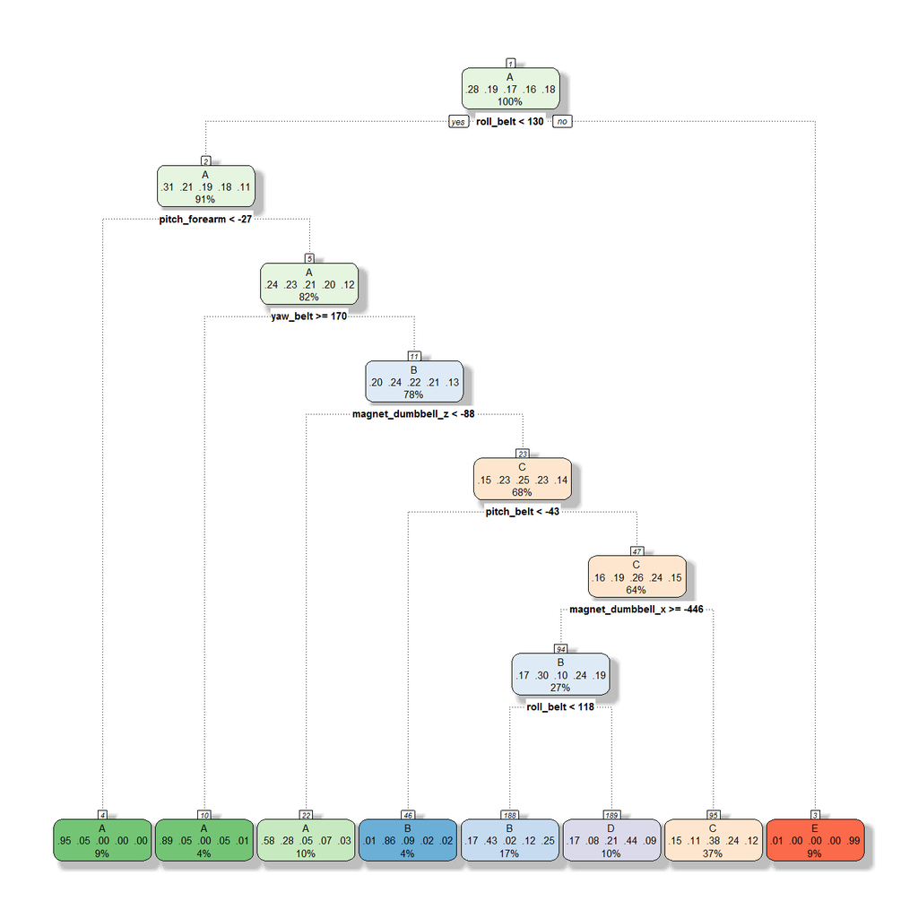

```r
fancyRpartPlot(model_DT$finalModel, sub = "")
```

### Appendix B. Correlation Matrix Visualization

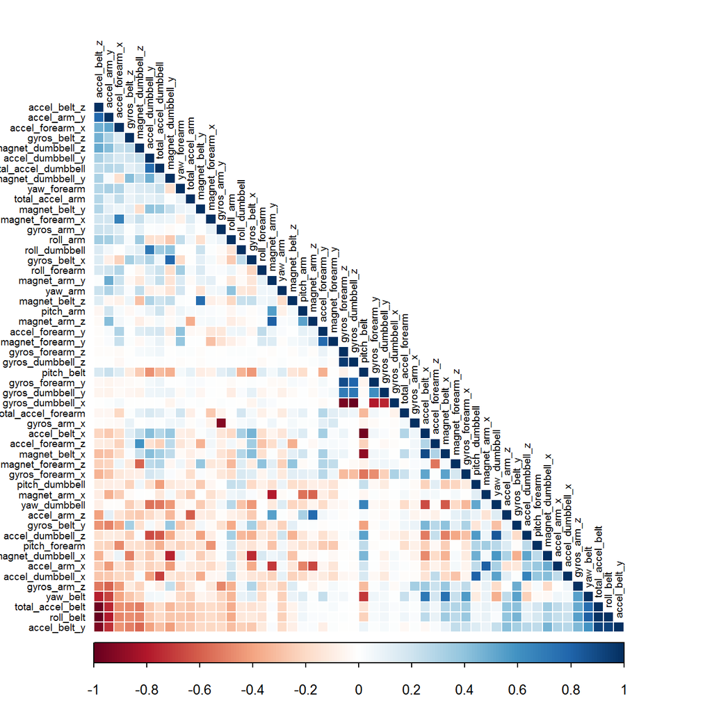

```r
# plot a correlation matrix
correlationMatrix <- cor(training[, -length(training)])
corrplot(correlationMatrix, method = "color", type = "lower", order = "FPC", tl.cex = 0.6,
         tl.col = rgb(0,0,0))
```